# NE_nuc_ratios_Mlp1_mitosis

This is a Python Jupyter notebook that carries out the analysis of line profiles drawn across nuclei to calculate nucleoplasm:nuclear envelope intensity ratios.

To run the entire notebook, click on "Runtime", then choose "Run All". Alternatively, you can click each individual code segment to run it one at a time.

First set up the environment and load needed packages.

```python
import matplotlib.pyplot as plt
from scipy.signal import find_peaks
import pandas as pd
import numpy as np
import os
```

Now we need to upload the CSV files to be anlyzed into the Colab environment.

```python
from google.colab import files

uploaded = files.upload()
```

Upload widget is only available when the cell has been executed in the current browser session. Please rerun this cell to enable.

[output not shown]

[output cut: 27 more lines]

Next we define custom function for finding peaks and calculating NE/nucleoplasm ratio. A peak finder tool is used to find the X positions that correspond to the nuclear envelope in the plot profiles. The intensities of these two peaks are averaged to get a single "NE" intensity value. Then we get the nucleoplasmic intensity value by averaging the intensity vales for the middle 50% of the plot profile between the two peaks.

After this function runs, you will see a plot showing the original data, with "X's" on the two peaks identified as the NE peaks. This method has worked well for us so far, but you may get into issues where it is hard to correctly identify the two NE peaks if the data is very noisy or if the nucleoplasmic signal is equal to or greater than the NE signal. You can visually confirm that the correct peaks were called, and if you see that it isn't working on your data we can brainstorm other options.

```python
def NucRatio(filename):
    #read in csv from plot profiles, find peaks from NE and Nucleoplasm in middle,
    #extract peak intensity values and calculate Nuc/NE ratio. Save output to dataframe
    npc = pd.read_csv(filename)
    name = filename
    X = np.array(npc.X)
    Y = np.array(npc.Y)
    bg = min(Y).astype(int)
    Y = Y-bg
    peaks, _ = find_peaks(Y, distance=2, prominence=75)
    print('Number of Peaks:', len(peaks))
    print(peaks)
    if len(peaks) != 2:
      plt.plot(Y)
      plt.plot(peaks, Y[peaks], "x")
      plt.minorticks_on()
      plt.grid(which='both', axis='both', linestyle='--')
      plt.title(name)
      plt.show()
      ne1=int(input("Choose NE1 Peak X position"))
      ne2=int(input("Choose NE2 Peak X position"))
      nes = np.array([ne1, ne2])
      print('NEs:', nes)
      peakRange = ne2-ne1
      print("Peak Dist.:", peakRange)
      peakMid = ((ne1+ne2)//2)
      print("Nuc Mid: ", peakMid)
      nucStart = int(ne1+(0.25*peakRange))
      nucEnd = int(ne2-(0.25*peakRange))
      print("NucStart: ", nucStart, "NucEnd: ", nucEnd)
      nucpoint = Y[peakMid]
      print("NucInt Point: ", nucpoint)
      nuc = np.mean(Y[nucStart:nucEnd])
      print("NucInt padded: ", nuc)
      ne1int = Y[ne1]
      ne2int = Y[ne2]
      nucRatio = nuc/((ne1int+ne2int)/2)
      output = [name,ne1int, ne2int, nuc, nucRatio]
      plt.plot(Y)
      plt.plot(peaks, Y[peaks], "x")
      plt.minorticks_on()
      plt.title(name)
      plt.grid(which='both', axis='both', linestyle='--')
      plt.show()
      return(output)
    else:
      ne1 = min(peaks)
      ne2 = max(peaks)
      nes = np.array([ne1, ne2])
      print('NEs:', nes)
      peakRange = ne2-ne1
      print("Peak Dist.:", peakRange)
      peakMid = ((ne1+ne2)//2)
      print("Nuc Mid: ", peakMid)
      nucStart = ne1+(0.25*peakRange).astype(int)
      nucEnd = ne2-(0.25*peakRange).astype(int)
      print("NucStart: ", nucStart, "NucEnd: ", nucEnd)
      nucpoint = Y[peakMid]
      print("NucInt Point: ", nucpoint)
      nuc = np.mean(Y[nucStart:nucEnd]).astype(int)
      print("NucInt padded: ", nuc)
      ne1int = Y[ne1]
      ne2int = Y[ne2]
      nucRatio = nuc/((ne1int+ne2int)/2)
      output = [name,ne1int, ne2int, nuc, nucRatio]
      plt.plot(Y)
      plt.plot(peaks, Y[peaks], "x")
      plt.minorticks_on()
      plt.title(name)
      plt.grid(which='both', axis='both', linestyle='--')
      plt.show()
      return(output)
```

Next, we can apply this function to one csv to see how it works.

```
You have uploaded 48 files.
```

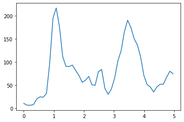

```python
data = list(uploaded)

print("You have uploaded", len(data), "files.")

check=pd.read_csv(data[0])
check.head()
type(check)

plt.plot("X", "Y", data=check)
```

Now we can apply this to all CSV files uploaded to the directory in batch.

```
Number of Peaks: 2
[10 32]
NEs: [10 32]
Peak Dist.: 22
Nuc Mid:  21
NucStart:  15 NucEnd:  27
NucInt Point:  44.873
NucInt padded:  58
```

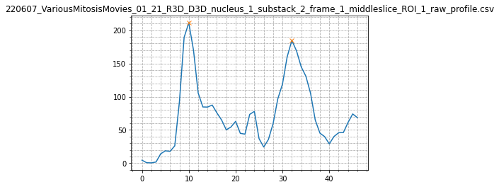

```
Number of Peaks: 2
[14 33]
NEs: [14 33]
Peak Dist.: 19
Nuc Mid:  23
NucStart:  18 NucEnd:  29
NucInt Point:  53.493
NucInt padded:  54
```

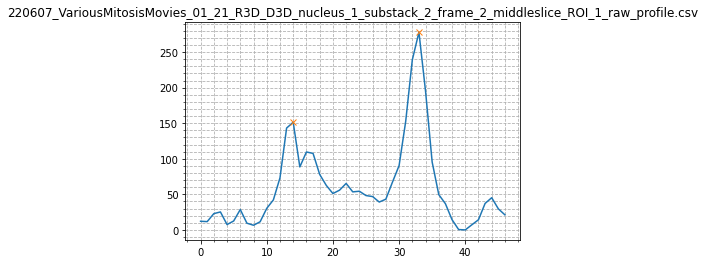

```
Number of Peaks: 2
[16 31]
NEs: [16 31]
Peak Dist.: 15
Nuc Mid:  23
NucStart:  19 NucEnd:  28
NucInt Point:  83.562
NucInt padded:  60
```

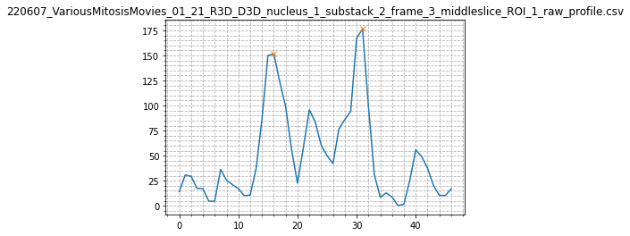

```
Number of Peaks: 2
[15 32]
NEs: [15 32]
Peak Dist.: 17
Nuc Mid:  23
NucStart:  19 NucEnd:  28
NucInt Point:  102.252
NucInt padded:  90
```

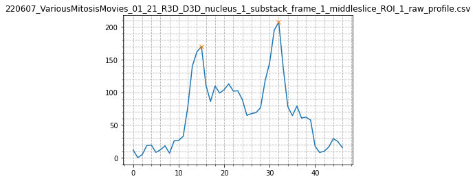

```
Number of Peaks: 3
[ 8 27 37]
```

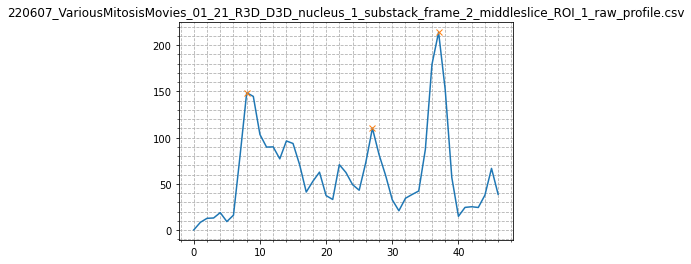

```
Choose NE1 Peak X position8
Choose NE2 Peak X position37
NEs: [ 8 37]
Peak Dist.: 29
Nuc Mid:  22
NucStart:  15 NucEnd:  29
NucInt Point:  70.892
NucInt padded:  63.095857142857135
```

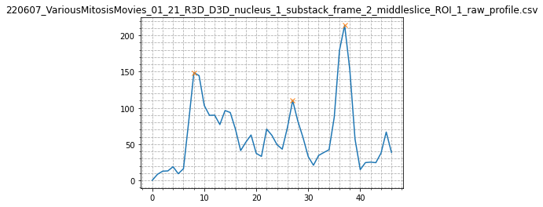

```
Number of Peaks: 1
[11]
```

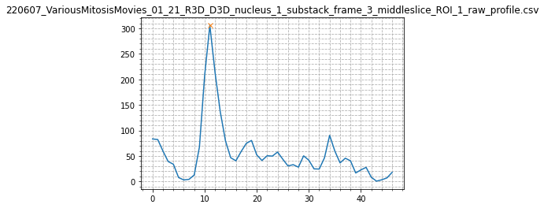

```
Choose NE1 Peak X position11
Choose NE2 Peak X position34
NEs: [11 34]
Peak Dist.: 23
Nuc Mid:  22
NucStart:  16 NucEnd:  28
NucInt Point:  50.434
NucInt padded:  51.056749999999994
```

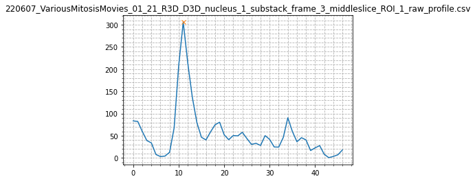

```
Number of Peaks: 2
[12 33]
NEs: [12 33]
Peak Dist.: 21
Nuc Mid:  22
NucStart:  17 NucEnd:  28
NucInt Point:  49.773
NucInt padded:  42
```

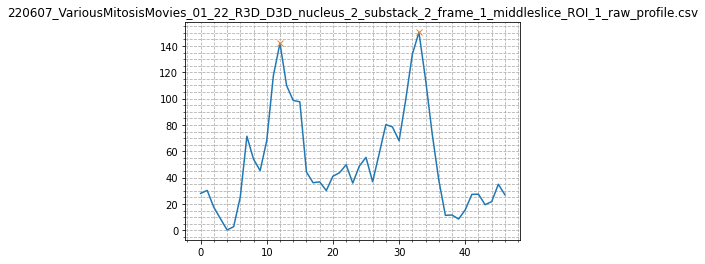

```
Number of Peaks: 2
[10 30]
NEs: [10 30]
Peak Dist.: 20
Nuc Mid:  20
NucStart:  15 NucEnd:  25
NucInt Point:  43.327
NucInt padded:  43
```

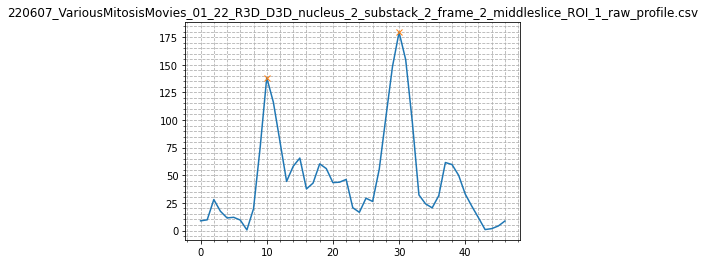

```
Number of Peaks: 2
[14 33]
NEs: [14 33]
Peak Dist.: 19
Nuc Mid:  23
NucStart:  18 NucEnd:  29
NucInt Point:  35.493
NucInt padded:  48
```

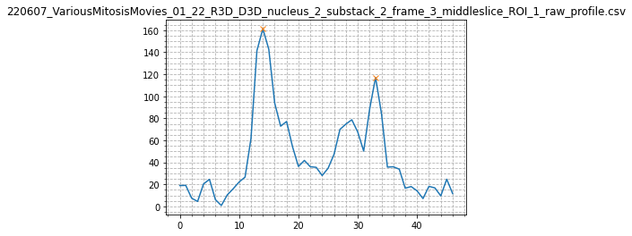

```
Number of Peaks: 2
[11 32]
NEs: [11 32]
Peak Dist.: 21
Nuc Mid:  21
NucStart:  16 NucEnd:  27
NucInt Point:  53.169
NucInt padded:  72
```

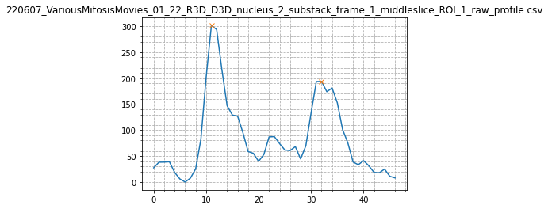

```
Number of Peaks: 2
[14 32]
NEs: [14 32]
Peak Dist.: 18
Nuc Mid:  23
NucStart:  18 NucEnd:  28
NucInt Point:  29.299
NucInt padded:  28
```

[39 more figures not shown]

```python
name_list=[]
ne1_list=[]
ne2_list=[]
nuc_list=[]
ratio_list=[]

for f in data:
    name,ne1int,ne2int,nuc,nucRatio = NucRatio(f)
    name_list.append(name)
    ne1_list.append(ne1int)
    ne2_list.append(ne2int)
    nuc_list.append(nuc)
    ratio_list.append(nucRatio)

df = pd.DataFrame({'Image': name_list, 'NE1_int': ne1_list,'NE2_int': ne2_list,'Nuc_int': nuc_list, 'Nuc_Ratio': ratio_list })
df = df[["Image", "NE1_int", "NE2_int", "Nuc_int", "Nuc_Ratio"]]
df.to_csv('NucRatios.csv')
```

If you are running this notebook in a Google Chrome browser, then the following code will automatically download the output as a CSV to your local computer. This only works within Chrome, so if you aren't using Chrome, you can manually download the output file by clicking the folder icon on the left side of the window. This will open the "Files" browser, and you should see all of the CSV files you uploaded, as well as the "NucRatios.csv" output file. Right click on the ouput file to bring up the options and download to your local computer.

```python
files.download('NucRatios.csv')
```

To see a plot of the ratio values calculated we can plot a histogram of the results.

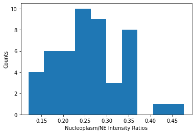

```python
%matplotlib inline

ratios = df.Nuc_Ratio

plt.hist(ratios, density=False, bins=10)
plt.ylabel("Counts")
plt.xlabel('Nucleoplasm/NE Intensity Ratios');
```

If you want to reuse this notebook for another data set, strain, experiment etc. then you can click on "Runtime" at the top of the page and click "Factory Reset Runtime". This will keep the Python code notebook but will remove all of the uploaded files and the generated output file. You can then repeat the analysis, this time uploading the new set of CSVs for the next analysis.